# Clustering_Exercise

Xu Yang

12/11/2017

This mini-project is based on the K-Means exercise from ‘R in Action’ Go here for the original blog post and solutions http://www.r-bloggers.com/k-means-clustering-from-r-in-action/

# Exercise 0: Install these packages if you don’t have them already

install.packages(c(“cluster”, “rattle.data”,“NbClust”))

Now load the data and look at the first few rows

```r
data(wine, package="rattle.data")
head(wine)
```

[output not shown]

# Exercise 1: Remove the first column from the data and scale it using the scale() function

```r
wine2<-scale(wine[-1])
```

Now we’d like to cluster the data using K-Means. How do we decide how many clusters to use if you don’t know that already? We’ll try two methods.

Method 1: A plot of the total within-groups sums of squares against the number of clusters in a K-means solution can be helpful. A bend in the graph can suggest the appropriate number of clusters.

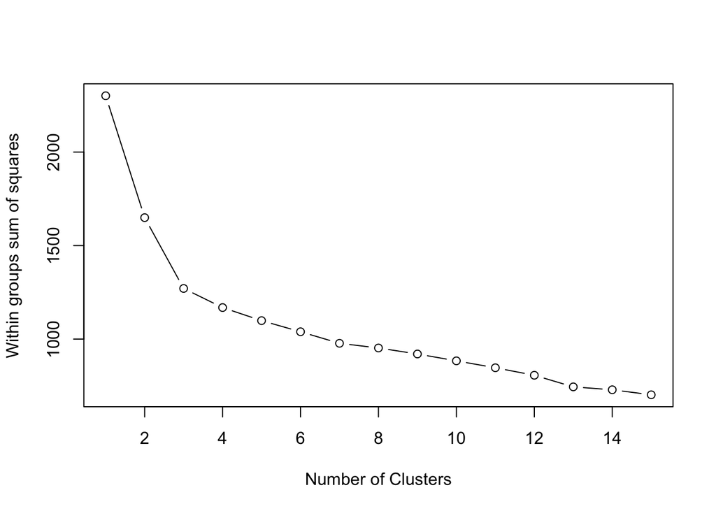

```r
wssplot <- function(data, nc=15, seed=1234){
                  wss <- (nrow(data)-1)*sum(apply(data,2,var))
                      for (i in 2:nc){
                set.seed(seed)
                    wss[i] <- sum(kmeans(data, centers=i)$withinss)}

              plot(1:nc, wss, type="b", xlab="Number of Clusters",
                            ylab="Within groups sum of squares")
       }

wssplot(wine2)
```

# Exercise 2:

- How many clusters does this method suggest?
- Why does this method work? What’s the intuition behind it?
- Look at the code for wssplot() and figure out how it works

Method 2: Use the NbClust library, which runs many experiments and gives a distribution of potential number of clusters.

```r
library(NbClust)
set.seed(1234)
nc <- NbClust(wine2, min.nc=2, max.nc=15, method="kmeans")
```

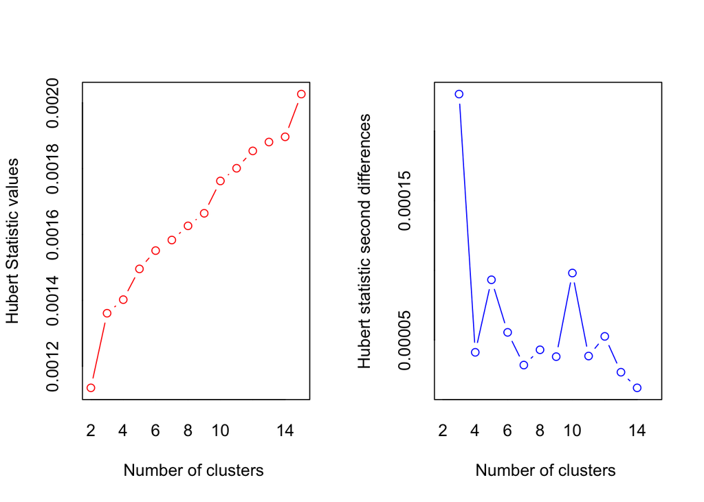

```
## *** : The Hubert index is a graphical method of determining the number of clusters.
##                 In the plot of Hubert index, we seek a significant knee that corresponds to a
##                 significant increase of the value of the measure i.e the significant peak in Hubert
##                 index second differences plot.
##
```

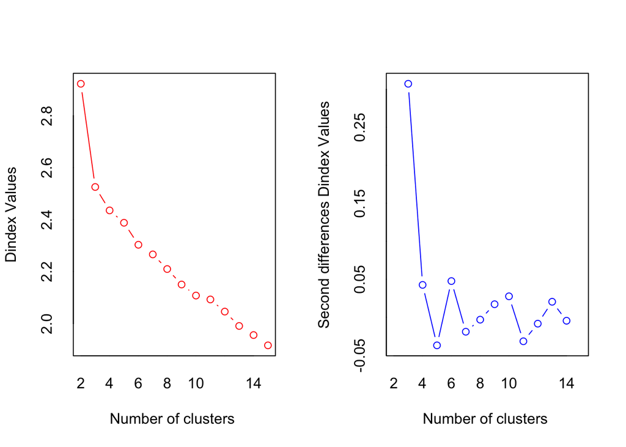

```
## *** : The D index is a graphical method of determining the number of clusters.
##                 In the plot of D index, we seek a significant knee (the significant peak in Dindex
##                 second differences plot) that corresponds to a significant increase of the value of
##                 the measure.
##
## * Among all indices:
## * 4 proposed 2 as the best number of clusters
## * 15 proposed 3 as the best number of clusters
## * 1 proposed 10 as the best number of clusters
## * 1 proposed 12 as the best number of clusters
## * 1 proposed 14 as the best number of clusters
## * 1 proposed 15 as the best number of clusters
##
##                    ***** Conclusion *****
##
## * According to the majority rule, the best number of clusters is  3
##
##
```

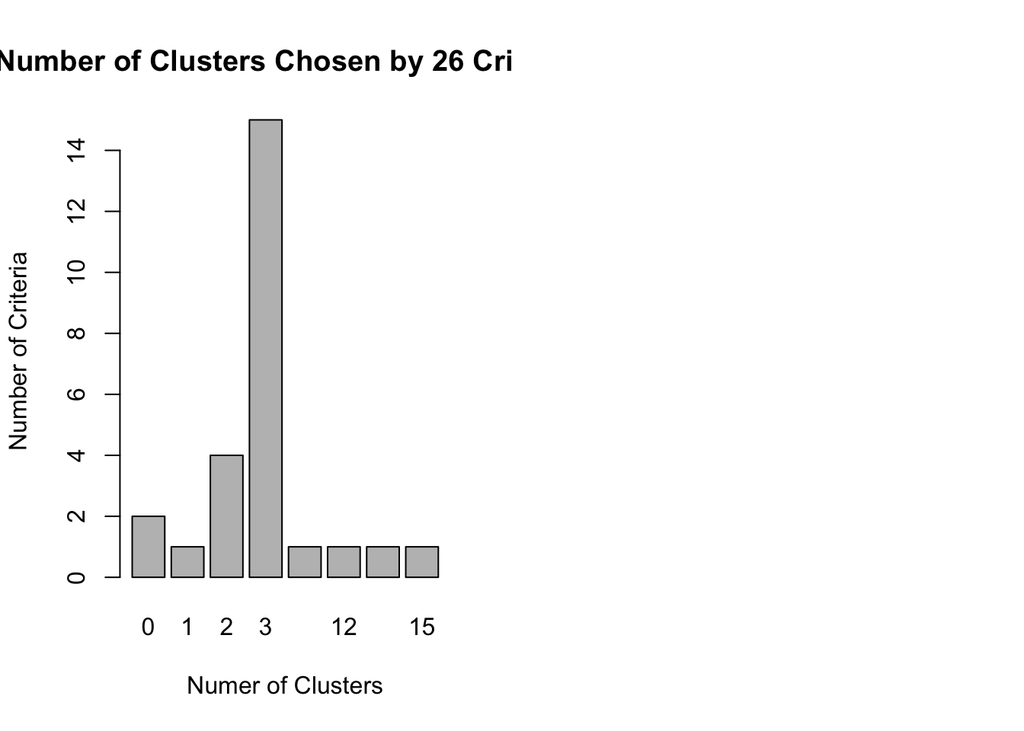

```r
barplot(table(nc$Best.n[1,]),
              xlab="Numer of Clusters", ylab="Number of Criteria",
                    main="Number of Clusters Chosen by 26 Criteria")
```

# Exercise 3: How many clusters does this method suggest?

Through barplot with NbClust function, we can see when number of clusters is 3, it has been chosen by more than 14 criteria which is obviously higher than other numbers.

Then this methos suggest 3 clusters.

# Exercise 4:

Once you’ve picked the number of clusters, run k-means using this number of clusters. Output the result of calling kmeans() into a variable fit.km

```r
set.seed(1234)
fit.km <- kmeans(wine2,centers=3,nstart=15)
```

Now we want to evaluate how well this clustering does.

# Exercise 5:

Using the table() function, show how the clusters in fit.km$clusters compares to the actual wine types in wine$Type. Would you consider this a good clustering?

```r
table(wine$Type,fit.km$cluster)
```

```
##
##      1  2  3
##   1 59  0  0
##   2  3 65  3
##   3  0  0 48
```

The table function shows all 59 observations with wine$Type=1 matched with cluster 1; 65 observations with wine$Type=2 matched with cluster 2, 3 matched with cluster 1, 3 matched with cluster 3; ALl 48 observations with wine$Type=3 matched with cluster 3; The overall accuracy is (59+65+48)/178=0.9663; It’s a good clustering.

# Exercise 6:

- Visualize these clusters using function clusplot() from the cluster library
- Would you consider this a good clustering?

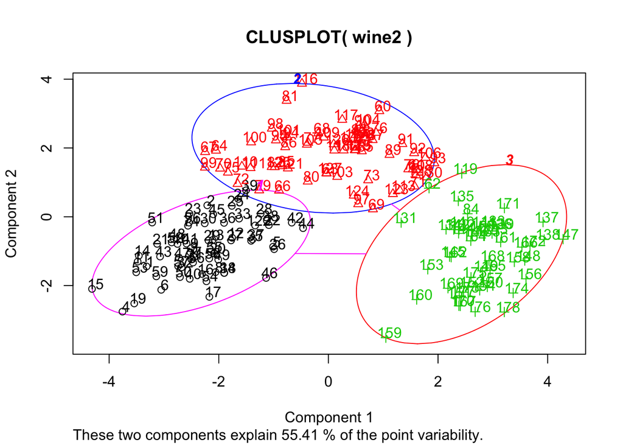

```r
library(cluster)
clusplot(wine2,fit.km$cluster,color = TRUE,col.p = fit.km$cluster,labels = 2)
```

On this plot, there are three clusters of points which color are red,green and black. Each cluster has minimun variance between cluster memberships. Distancess from green cluster to red cluster and to black cluster are as big as possible. Red cluster overlap a bit with black cluster. This is a good clustering.